# Recursos 14

8 actividades; 5 operarios; interrumpir o no interrumpir

# Enunciado

Considere el proyecto cuyo cuadro de prelaciones, duraciones (semanas) y operarios necesarios se adjunta, con 5 operarios disponibles. Se discute si merece la pena organizar el trabajo de modo que una actividad pueda interrumpirse y reanudarse más tarde (sin coste añadido) cuando los operarios hagan falta en otra más urgente.

1. Programe el proyecto con un planificador en paralelo y la regla «menor holgura total primero» suponiendo que las actividades **no** pueden interrumpirse. ¿Cuánto dura?

2. Repita suponiendo que sí pueden interrumpirse: en cada semana se vuelven a ordenar *todas* las actividades disponibles, también las empezadas, y una actividad en curso puede quedar parada si entra otra más prioritaria. ¿Cuánto dura? ¿Qué actividades se interrumpen y cuántas veces?

3. Compare las dos programaciones semana a semana. ¿De dónde sale la ganancia (si la hay)?

4. ¿Qué costes ocultos tiene interrumpir una actividad en la práctica? ¿Cuándo compensa?

Tabla 1: Cuadro de datos del enunciado

| activity | predecessor | duration | resources |
| --- | --- | --- | --- |
| A | --- | 6 | 4 |
| B | --- | 3 | 3 |
| C | --- | 8 | 1 |
| D | A,B | 4 | 3 |
| E | A,B | 6 | 4 |
| F | C,E | 2 | 1 |
| G | D,F | 2 | 1 |
| H | G | 2 | 1 |

El proyecto corresponde al lanzamiento de una aplicación móvil; las actividades son las siguientes (las duraciones del cuadro están en semanas).

Tabla 2: Descripción de las actividades

|  | Descripción |
| --- | --- |
| A | Estudio de requisitos |
| B | Diseño de la arquitectura |
| C | Diseño de interfaz y prototipo |
| D | Base de datos y modelo |
| E | API del servidor |
| F | Pantallas principales |
| G | Módulo de pagos |
| H | Notificaciones y sincronización |

# Resolución

## Apartado 1

1. Programe el proyecto con un planificador en paralelo y la regla «menor holgura total primero» suponiendo que las actividades **no** pueden interrumpirse. ¿Cuánto dura?

Cálculo de los tiempos mínimos y máximos de los nodos del grafo Roy paso a paso. El primer paso muestra el grafo resuelto; a partir del siguiente se calcula desde el principio (avance con los botones):

[figure not shown]

paso 0 de 22

[figure not shown]

Figura 1: Grafo Roy con tiempos y camino crítico (sin límite de operarios)

Tabla 3: Calendario sin límite de recursos (la regla de prioridad usa la holgura total)

[figure not shown]

ninguna celda (0 de 64)

[figure not shown]

Haz clic en un número de la tabla para ver cómo se calcula.

👆 **Interactivo:** haz clic en cualquier celda de la tabla para ver cómo se calcula (otro clic la deselecciona), o usa los botones y las flechas del teclado.

| Actividad | Duración | Inicio más temprano | Fin más temprano | Inicio más tardío | Fin más tardío | H total | H libre | H independiente |
| --- | --- | --- | --- | --- | --- | --- | --- | --- |
| A | 6 | 0 | 6 | 0 | 6 | 0 | 0 | 0 |
| B | 3 | 0 | 3 | 3 | 6 | 3 | 3 | 3 |
| C | 8 | 0 | 8 | 4 | 12 | 4 | 4 | 4 |
| D | 4 | 6 | 10 | 10 | 14 | 4 | 4 | 4 |
| E | 6 | 6 | 12 | 6 | 12 | 0 | 0 | 0 |
| F | 2 | 12 | 14 | 12 | 14 | 0 | 0 | 0 |
| G | 2 | 14 | 16 | 14 | 16 | 0 | 0 | 0 |
| H | 2 | 16 | 18 | 16 | 18 | 0 | 0 | 0 |

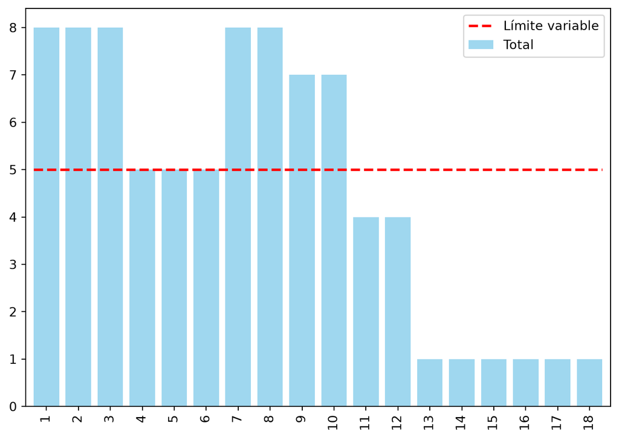

Figura 2: Cargas con los inicios más tempranos frente al límite

El planificador recorre las semanas: una actividad es *disponible* cuando han terminado sus predecesoras; las disponibles se ordenan por la regla (menor holgura total, luego menor duración, luego orden alfabético) y entran mientras quepan en el límite. Sin interrupciones, las ya empezadas van primero. La primera tabla recoge las semanas en que alguna actividad disponible tiene que esperar y por qué; la segunda, el Gantt de operarios.

Tabla 4: Esperas sin interrupciones

| semana | orden de prioridad | trabajan | esperan (no caben) |
| --- | --- | --- | --- |
| 1 | A (H=0, d=6, 4 op.) › B (H=3, d=3, 3 op.) › C (H=4, d=8, 1 op.) | A, C | B: 4 + 3 = 7 > 5 |
| 2 | A (en curso, 4 op.) › C (en curso, 1 op.) › B (H=3, d=3, 3 op.) | A, C | B: 5 + 3 = 8 > 5 |
| 3 | A (en curso, 4 op.) › C (en curso, 1 op.) › B (H=3, d=3, 3 op.) | A, C | B: 5 + 3 = 8 > 5 |
| 4 | A (en curso, 4 op.) › C (en curso, 1 op.) › B (H=3, d=3, 3 op.) | A, C | B: 5 + 3 = 8 > 5 |
| 5 | A (en curso, 4 op.) › C (en curso, 1 op.) › B (H=3, d=3, 3 op.) | A, C | B: 5 + 3 = 8 > 5 |
| 6 | A (en curso, 4 op.) › C (en curso, 1 op.) › B (H=3, d=3, 3 op.) | A, C | B: 5 + 3 = 8 > 5 |
| 10 | E (H=0, d=6, 4 op.) › D (H=4, d=4, 3 op.) | E | D: 4 + 3 = 7 > 5 |
| 11 | E (en curso, 4 op.) › D (H=4, d=4, 3 op.) | E | D: 4 + 3 = 7 > 5 |
| 12 | E (en curso, 4 op.) › D (H=4, d=4, 3 op.) | E | D: 4 + 3 = 7 > 5 |
| 13 | E (en curso, 4 op.) › D (H=4, d=4, 3 op.) | E | D: 4 + 3 = 7 > 5 |
| 14 | E (en curso, 4 op.) › D (H=4, d=4, 3 op.) | E | D: 4 + 3 = 7 > 5 |
| 15 | E (en curso, 4 op.) › D (H=4, d=4, 3 op.) | E | D: 4 + 3 = 7 > 5 |

Tabla 5: Programación sin interrupciones

(a)

[figure not shown]

**Respuesta:** sin interrupciones el proyecto dura **23 semanas**, 5 más que sin límite de operarios (18).

## Apartado 2

2. Repita suponiendo que sí pueden interrumpirse: en cada semana se vuelven a ordenar *todas* las actividades disponibles, también las empezadas, y una actividad en curso puede quedar parada si entra otra más prioritaria. ¿Cuánto dura? ¿Qué actividades se interrumpen y cuántas veces?

Ahora, cada semana se ordenan por la misma regla *todas* las disponibles, también las empezadas: una actividad en curso deja de trabajar esa semana si otras de más prioridad ocupan los operarios.

Tabla 6: Esperas con interrupciones permitidas

| semana | orden de prioridad | trabajan | esperan (no caben) |
| --- | --- | --- | --- |
| 1 | A (H=0, d=6, 4 op.) › B (H=3, d=3, 3 op.) › C (H=4, d=8, 1 op.) | A, C | B: 4 + 3 = 7 > 5 |
| 2 | A (en curso, 4 op.) › B (H=3, d=3, 3 op.) › C (en curso, 1 op.) | A, C | B: 4 + 3 = 7 > 5 |
| 3 | A (en curso, 4 op.) › B (H=3, d=3, 3 op.) › C (en curso, 1 op.) | A, C | B: 4 + 3 = 7 > 5 |
| 4 | A (en curso, 4 op.) › B (H=3, d=3, 3 op.) › C (en curso, 1 op.) | A, C | B: 4 + 3 = 7 > 5 |
| 5 | A (en curso, 4 op.) › B (H=3, d=3, 3 op.) › C (en curso, 1 op.) | A, C | B: 4 + 3 = 7 > 5 |
| 6 | A (en curso, 4 op.) › B (H=3, d=3, 3 op.) › C (en curso, 1 op.) | A, C | B: 4 + 3 = 7 > 5 |
| 10 | E (H=0, d=6, 4 op.) › D (H=4, d=4, 3 op.) | E | D: 4 + 3 = 7 > 5 |
| 11 | E (en curso, 4 op.) › D (H=4, d=4, 3 op.) | E | D: 4 + 3 = 7 > 5 |
| 12 | E (en curso, 4 op.) › D (H=4, d=4, 3 op.) | E | D: 4 + 3 = 7 > 5 |
| 13 | E (en curso, 4 op.) › D (H=4, d=4, 3 op.) | E | D: 4 + 3 = 7 > 5 |
| 14 | E (en curso, 4 op.) › D (H=4, d=4, 3 op.) | E | D: 4 + 3 = 7 > 5 |
| 15 | E (en curso, 4 op.) › D (H=4, d=4, 3 op.) | E | D: 4 + 3 = 7 > 5 |

Tabla 7: Programación con interrupciones permitidas

(a)

[figure not shown]

**Respuesta:** con interrupciones el proyecto dura **23 semanas**. Ninguna actividad llega a interrumpirse: en ninguna semana aparece una actividad disponible más prioritaria que otra ya en curso y que necesite sus operarios.

## Apartado 3

3. Compare las dos programaciones semana a semana. ¿De dónde sale la ganancia (si la hay)?

Tabla 8: Inicio y fin de cada actividad en las dos programaciones

|  | inicio (no interr.) | fin (no interr.) | inicio (interr.) | fin (interr.) | semanas trabajadas (interr.) |
| --- | --- | --- | --- | --- | --- |
| A | 1 | 6 | 1 | 6 | 6 |
| B | 7 | 9 | 7 | 9 | 3 |
| C | 1 | 8 | 1 | 8 | 8 |
| D | 16 | 19 | 16 | 19 | 4 |
| E | 10 | 15 | 10 | 15 | 6 |
| F | 16 | 17 | 16 | 17 | 2 |
| G | 20 | 21 | 20 | 21 | 2 |
| H | 22 | 23 | 22 | 23 | 2 |

**Respuesta:** 23 semanas sin interrupciones frente a 23 con ellas. No hay ganancia: las dos programaciones coinciden semana a semana; la regla de prioridad ya evitaba bloquear los operarios con actividades holgadas. Ojo: el planificador es una heurística, así que permitir interrupciones no garantiza mejorar (puede incluso empeorar) y, cuando mejora, fragmenta el trabajo.

## Apartado 4

4. ¿Qué costes ocultos tiene interrumpir una actividad en la práctica? ¿Cuándo compensa?

**Respuesta:** interrumpir tiene costes que el modelo ignora: volver a montar y desmontar (tiempos de preparación), pérdida de ritmo y de aprendizaje, el material en curso inmovilizado, la coordinación de los operarios y la dificultad de seguimiento. Compensa cuando el ahorro de plazo vale más que esos costes: actividades largas, modulares (pueden partirse en lotes) y sin costes de preparación apreciables; no compensa en tareas con fraguados, curados o procesos continuos.